# Lab 6: igraphs

Makesh Srinivasan

10/6/2022

Registration number: 19BCE1717  
Faculty: Prof. Parvathi R  
Slot: L55 + L56  
Course code: CSE3020

## igraph Lab exercise

##### Do the following questions

##### Prerequisites

Do the following before proceeding to the questions

```r
# install.packages("igraph")
library(igraph) # load the library
```

##### Solutions

1. Read the given adjacency matrix into R (adjacency.csv )

```r
nodes <- read.csv("Dataset2-Media-User-Example-NODES.csv") #nodes
head(nodes)
```

```
##    id   media media.type media.name audience.size
## 1 s01     NYT          1  Newspaper            20
## 2 s02    WaPo          1  Newspaper            25
## 3 s03     WSJ          1  Newspaper            30
## 4 s04    USAT          1  Newspaper            32
## 5 s05 LATimes          1  Newspaper            20
## 6 s06     CNN          2         TV            56
```

2. Read the given edge matrix into R(edges.csv)

```r
edges <- read.csv("Dataset2-Media-User-Example-EDGES.csv") #links
edges <- subset(edges, select = -c(X))
head(edges)
```

```
##   U01 U02 U03 U04 U05 U06 U07 U08 U09 U10 U11 U12 U13 U14 U15 U16 U17 U18 U19
## 1   1   1   1   0   0   0   0   0   0   0   0   0   0   0   0   0   0   0   0
## 2   0   0   0   1   1   0   0   0   0   0   0   0   0   0   0   0   0   0   0
## 3   0   0   0   0   0   1   1   1   1   0   0   0   0   0   0   0   0   0   0
## 4   0   0   0   0   0   0   0   0   1   1   1   0   0   0   0   0   0   0   0
## 5   0   0   0   0   0   0   0   0   0   0   1   1   1   0   0   0   0   0   0
## 6   0   0   0   0   0   0   0   0   0   0   0   0   1   1   0   0   1   0   0
##   U20
## 1   0
## 2   1
## 3   0
## 4   0
## 5   0
## 6   0
```

3. Create and plot the graph from the adjacency matrix and edge matrix (customize the vertex color edge size, vertex frame and label)

```r
# The plots contain all the customisations too. But to see them individually, see the following chunk of code
net2 <- graph_from_incidence_matrix(edges)
table(V(net2)$type)
```

```
##
## FALSE  TRUE
##    10    20
```

```r
net2.bp <- bipartite.projection(net2)
as_incidence_matrix(net2)  %*% t(as_incidence_matrix(net2))
```

```
##    1 2 3 4 5 6 7 8 9 10
## 1  3 0 0 0 0 0 0 0 0  1
## 2  0 3 0 0 0 0 0 0 1  0
## 3  0 0 4 1 0 0 0 0 1  0
## 4  0 0 1 3 1 0 0 0 0  1
## 5  0 0 0 1 3 1 0 0 0  1
## 6  0 0 0 0 1 3 1 1 0  0
## 7  0 0 0 0 0 1 3 1 0  0
## 8  0 0 0 0 0 1 1 4 1  0
## 9  0 1 1 0 0 0 0 1 3  0
## 10 1 0 0 1 1 0 0 0 0  2
```

```r
t(as_incidence_matrix(net2)) %*%   as_incidence_matrix(net2)
```

```
##     U01 U02 U03 U04 U05 U06 U07 U08 U09 U10 U11 U12 U13 U14 U15 U16 U17 U18 U19
## U01   2   1   1   0   0   0   0   0   0   0   1   0   0   0   0   0   0   0   0
## U02   1   1   1   0   0   0   0   0   0   0   0   0   0   0   0   0   0   0   0
## U03   1   1   1   0   0   0   0   0   0   0   0   0   0   0   0   0   0   0   0
## U04   0   0   0   1   1   0   0   0   0   0   0   0   0   0   0   0   0   0   0
## U05   0   0   0   1   1   0   0   0   0   0   0   0   0   0   0   0   0   0   0
## U06   0   0   0   0   0   2   1   1   1   0   0   0   0   0   0   0   0   0   1
## U07   0   0   0   0   0   1   1   1   1   0   0   0   0   0   0   0   0   0   0
## U08   0   0   0   0   0   1   1   1   1   0   0   0   0   0   0   0   0   0   0
## U09   0   0   0   0   0   1   1   1   2   1   1   0   0   0   0   0   0   0   0
## U10   0   0   0   0   0   0   0   0   1   1   1   0   0   0   0   0   0   0   0
## U11   1   0   0   0   0   0   0   0   1   1   3   1   1   0   0   0   0   0   0
## U12   0   0   0   0   0   0   0   0   0   0   1   1   1   0   0   0   0   0   0
## U13   0   0   0   0   0   0   0   0   0   0   1   1   2   1   0   0   1   0   0
## U14   0   0   0   0   0   0   0   0   0   0   0   0   1   2   1   1   1   0   0
## U15   0   0   0   0   0   0   0   0   0   0   0   0   0   1   1   1   0   0   0
## U16   0   0   0   0   0   0   0   0   0   0   0   0   0   1   1   2   1   1   1
## U17   0   0   0   0   0   0   0   0   0   0   0   0   1   1   0   1   2   1   1
## U18   0   0   0   0   0   0   0   0   0   0   0   0   0   0   0   1   1   1   1
## U19   0   0   0   0   0   1   0   0   0   0   0   0   0   0   0   1   1   1   2
## U20   0   0   0   1   1   1   0   0   0   0   0   0   0   0   0   0   0   0   1
##     U20
## U01   0
## U02   0
## U03   0
## U04   1
## U05   1
## U06   1
## U07   0
## U08   0
## U09   0
## U10   0
## U11   0
## U12   0
## U13   0
## U14   0
## U15   0
## U16   0
## U17   0
## U18   0
## U19   1
## U20   2
```

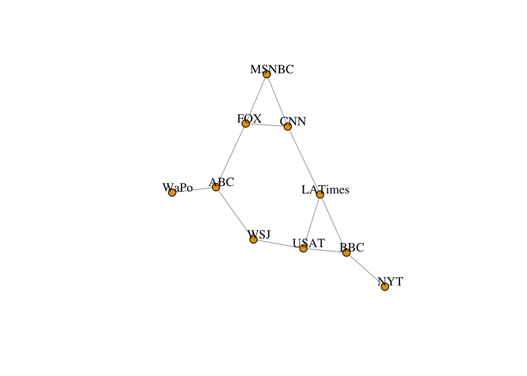

```r
plot(net2.bp$proj1, vertex.label.color="black", vertex.label.dist=1,vertex.size=7, vertex.label=nodes$media[!is.na(nodes$media.type)])
```

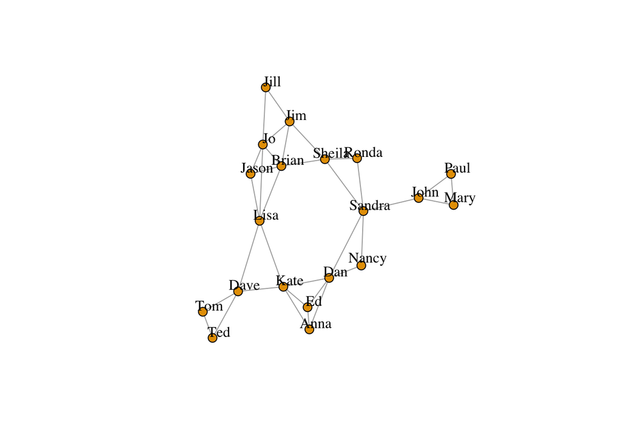

```r
plot(net2.bp$proj2, vertex.label.color="black", vertex.label.dist=1,vertex.size=7, vertex.label=nodes$media[ is.na(nodes$media.type)])
```

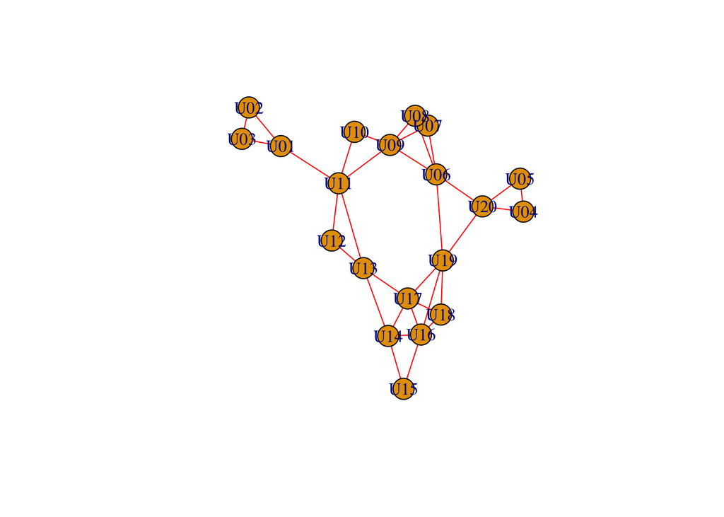

```r
# Individual customisations
#####edge
#colour
plot(net2.bp$proj2, edge.color="red")
```

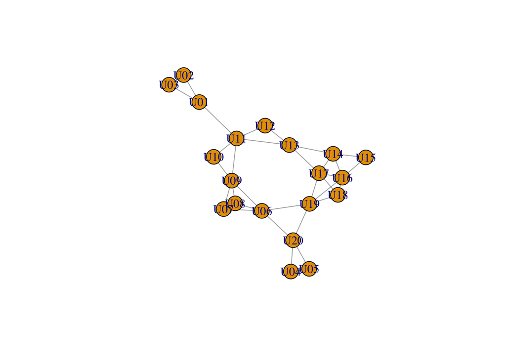

```r
#size
plot(net2.bp$proj2, edge.arrow.size=10)
```

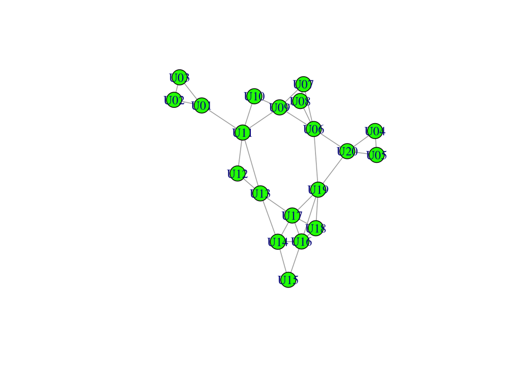

```r
#####vertex
#colour
plot(net2.bp$proj2, vertex.color="green")
```

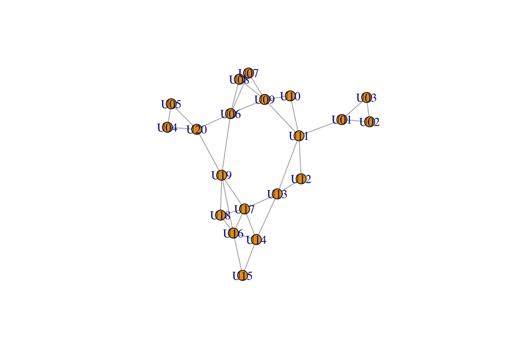

```r
#size
plot(net2.bp$proj2, vertex.size = 10)
```

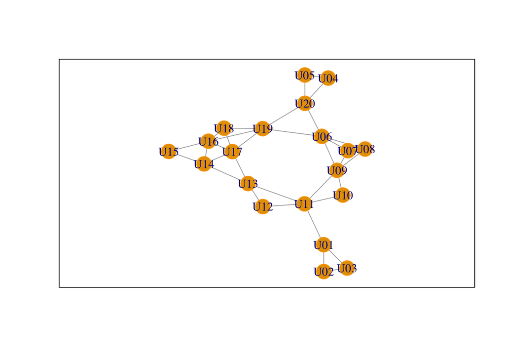

```r
#vector frame
plot(net2.bp$proj2, frame =TRUE, vertex.frame.color = "orange")
```

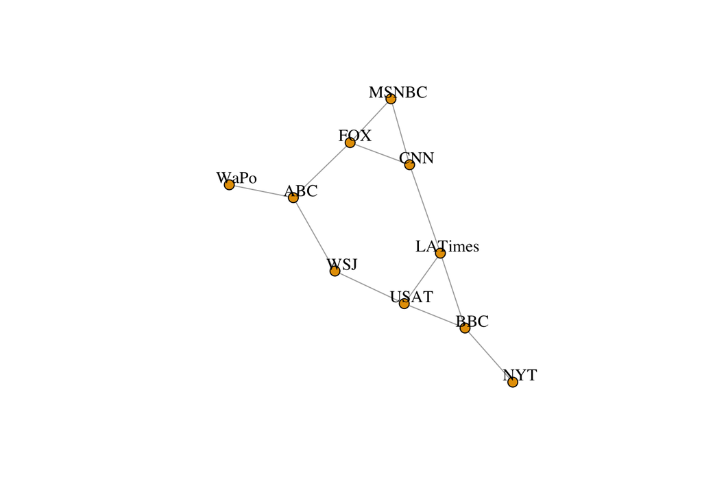

```r
#label
plot(net2.bp$proj1, vertex.label.color="black", vertex.label.dist=1,vertex.size=7, vertex.label=nodes$media[!is.na(nodes$media.type)])
```

4. Display the edges & vertices, the network as matrix and the names of vertices

```r
##### This can be printed as a matrix as shown below:
E(net2)
```

```
## + 31/31 edges from 55787c8 (vertex names):
##  [1] 1 --U01 1 --U02 1 --U03 2 --U04 2 --U05 2 --U20 3 --U06 3 --U07 3 --U08
## [10] 3 --U09 4 --U09 4 --U10 4 --U11 5 --U11 5 --U12 5 --U13 6 --U13 6 --U14
## [19] 6 --U17 7 --U14 7 --U15 7 --U16 8 --U16 8 --U17 8 --U18 8 --U19 9 --U06
## [28] 9 --U19 9 --U20 10--U01 10--U11
```

```r
V(net2)
```

```
## + 30/30 vertices, named, from 55787c8:
##  [1] 1   2   3   4   5   6   7   8   9   10  U01 U02 U03 U04 U05 U06 U07 U08 U09
## [20] U10 U11 U12 U13 U14 U15 U16 U17 U18 U19 U20
```

```r
edges
```

```
##    U01 U02 U03 U04 U05 U06 U07 U08 U09 U10 U11 U12 U13 U14 U15 U16 U17 U18 U19
## 1    1   1   1   0   0   0   0   0   0   0   0   0   0   0   0   0   0   0   0
## 2    0   0   0   1   1   0   0   0   0   0   0   0   0   0   0   0   0   0   0
## 3    0   0   0   0   0   1   1   1   1   0   0   0   0   0   0   0   0   0   0
## 4    0   0   0   0   0   0   0   0   1   1   1   0   0   0   0   0   0   0   0
## 5    0   0   0   0   0   0   0   0   0   0   1   1   1   0   0   0   0   0   0
## 6    0   0   0   0   0   0   0   0   0   0   0   0   1   1   0   0   1   0   0
## 7    0   0   0   0   0   0   0   0   0   0   0   0   0   1   1   1   0   0   0
## 8    0   0   0   0   0   0   0   0   0   0   0   0   0   0   0   1   1   1   1
## 9    0   0   0   0   0   1   0   0   0   0   0   0   0   0   0   0   0   0   1
## 10   1   0   0   0   0   0   0   0   0   0   1   0   0   0   0   0   0   0   0
##    U20
## 1    0
## 2    1
## 3    0
## 4    0
## 5    0
## 6    0
## 7    0
## 8    0
## 9    1
## 10   0
```

```r
##### This can also be printed as a heatmap as shown below (I used weights from a different dataset)
n <- read.csv("Dataset1-Media-Example-NODES.csv", header=T, as.is=T)
l <- read.csv("Dataset1-Media-Example-EDGES.csv", header=T, as.is=T)
l <- aggregate(l[,3], l[,-3], sum)
l <- l[order(l$from, l$to),]
colnames(l)[4] <- "weight"
rownames(l) <- NULL
net <- graph_from_data_frame(d=l, vertices=n, directed=T)
class(net)
```

```
## [1] "igraph"
```

```r
graph <- net
net <- simplify(net, remove.multiple = F, remove.loops = T)
as_edgelist(net, names=T)
```

```
##       [,1]  [,2]
##  [1,] "s01" "s02"
##  [2,] "s01" "s03"
##  [3,] "s01" "s04"
##  [4,] "s01" "s15"
##  [5,] "s02" "s01"
##  [6,] "s02" "s03"
##  [7,] "s02" "s09"
##  [8,] "s02" "s10"
##  [9,] "s03" "s01"
## [10,] "s03" "s04"
## [11,] "s03" "s05"
## [12,] "s03" "s08"
## [13,] "s03" "s10"
## [14,] "s03" "s11"
```

[output cut: 34 more lines]

```r
as_adjacency_matrix(net, attr="weight")
```

```
## 17 x 17 sparse Matrix of class "dgCMatrix"
```

```
##    [[ suppressing 17 column names 's01', 's02', 's03' ... ]]
```

```
##
## s01  . 22 22 21 .  .  .  .  .  .  .  .  .  . 20  .  .
## s02 23  . 21  . .  .  .  .  1  5  .  .  .  .  .  .  .
## s03 21  .  . 22 1  .  .  4  .  2  1  1  .  .  .  .  .
## s04  .  . 23  . .  1  .  .  .  . 22  3  .  .  .  .  2
## s05  1 21  .  . .  .  .  .  2  .  .  .  .  . 21  .  .
## s06  .  .  .  . .  .  .  .  .  .  .  .  .  .  . 21 21
## s07  .  .  1  . .  .  . 22  . 21  .  .  .  4  .  .  .
## s08  .  .  2  . .  . 21  . 23  .  .  .  .  .  .  .  .
## s09  .  .  .  . .  .  .  .  . 21  .  .  .  .  .  .  .
## s10  .  .  2  . .  .  .  .  .  .  .  .  .  .  .  .  .
## s11  .  .  .  . .  .  .  .  .  .  .  .  .  .  .  .  .
## s12  .  .  .  . .  2  .  .  .  .  .  . 22 22  .  .  .
## s13  .  .  .  . .  .  .  .  .  .  . 21  .  .  .  .  1
## s14  .  .  .  . .  .  .  .  .  .  1  . 21  .  .  .  .
## s15 22  .  .  1 .  4  .  .  .  .  .  .  .  .  .  .  .
## s16  .  .  .  . . 23  .  .  .  .  .  .  .  .  .  . 21
## s17  .  .  .  4 .  .  .  .  .  .  .  .  .  .  .  .  .
```

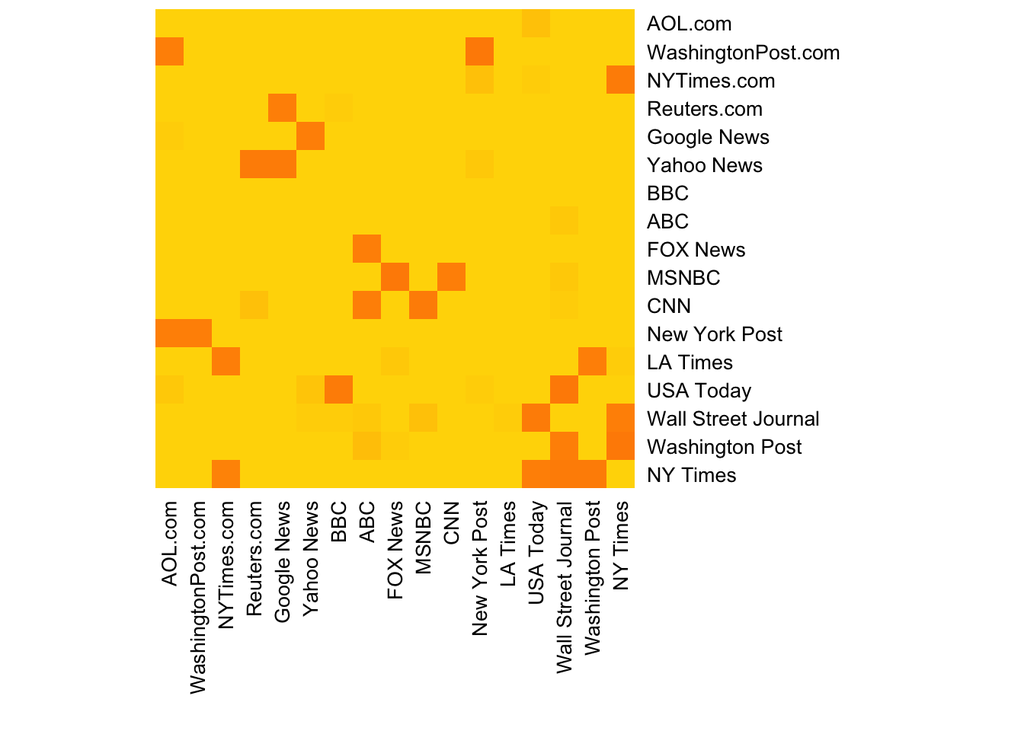

```r
netm <- get.adjacency(net, attr="weight", sparse=F)
colnames(netm) <- V(net)$media
rownames(netm) <- V(net)$media
palf <- colorRampPalette(c("gold", "dark orange"))
heatmap(netm[,17:1], Rowv = NA, Colv = NA, col = palf(100), scale="none", margins=c(10,10) )
```

5. Find the count of vertices and edges of the created graph

```r
x <- gsize(net2)
y <- gorder(net2)
print(paste("count of edges = ", x))
```

```
## [1] "count of edges =  31"
```

```r
print(paste("count of vertices = ", y))
```

```
## [1] "count of vertices =  30"
```

6. Display the adjacency vertices of each vertex(individual) in the created graph

```r
adjacent_vertices(graph, V(graph), mode = "out")
```

```
## $s01
## + 4/17 vertices, named, from 54c0947:
## [1] s02 s03 s04 s15
##
## $s02
## + 4/17 vertices, named, from 54c0947:
## [1] s01 s03 s09 s10
##
## $s03
## + 7/17 vertices, named, from 54c0947:
## [1] s01 s04 s05 s08 s10 s11 s12
##
## $s04
## + 5/17 vertices, named, from 54c0947:
## [1] s03 s06 s11 s12 s17
##
## $s05
## + 4/17 vertices, named, from 54c0947:
## [1] s01 s02 s09 s15
##
## $s06
## + 3/17 vertices, named, from 54c0947:
## [1] s06 s16 s17
##
## $s07
## + 4/17 vertices, named, from 54c0947:
## [1] s03 s08 s10 s14
##
## $s08
## + 3/17 vertices, named, from 54c0947:
## [1] s03 s07 s09
##
## $s09
## + 1/17 vertex, named, from 54c0947:
## [1] s10
##
## $s10
## + 1/17 vertex, named, from 54c0947:
## [1] s03
##
```

[output cut: 11 more lines]

```
## $s14
## + 2/17 vertices, named, from 54c0947:
## [1] s11 s13
##
## $s15
## + 3/17 vertices, named, from 54c0947:
## [1] s01 s04 s06
##
## $s16
## + 2/17 vertices, named, from 54c0947:
## [1] s06 s17
##
## $s17
## + 1/17 vertex, named, from 54c0947:
## [1] s04
```

```r
adjacent_vertices(graph, V(graph), mode = "in")
```

```
## $s01
## + 4/17 vertices, named, from 54c0947:
## [1] s02 s03 s05 s15
##
## $s02
## + 2/17 vertices, named, from 54c0947:
## [1] s01 s05
##
## $s03
## + 6/17 vertices, named, from 54c0947:
## [1] s01 s02 s04 s07 s08 s10
##
## $s04
## + 4/17 vertices, named, from 54c0947:
## [1] s01 s03 s15 s17
##
## $s05
## + 1/17 vertex, named, from 54c0947:
## [1] s03
##
## $s06
## + 5/17 vertices, named, from 54c0947:
## [1] s04 s06 s12 s15 s16
##
## $s07
## + 1/17 vertex, named, from 54c0947:
## [1] s08
##
## $s08
## + 2/17 vertices, named, from 54c0947:
## [1] s03 s07
##
## $s09
## + 3/17 vertices, named, from 54c0947:
## [1] s02 s05 s08
##
## $s10
## + 4/17 vertices, named, from 54c0947:
## [1] s02 s03 s07 s09
##
```

[output cut: 12 more lines]

```
## $s14
## + 2/17 vertices, named, from 54c0947:
## [1] s07 s12
##
## $s15
## + 2/17 vertices, named, from 54c0947:
## [1] s01 s05
##
## $s16
## + 1/17 vertex, named, from 54c0947:
## [1] s06
##
## $s17
## + 4/17 vertices, named, from 54c0947:
## [1] s04 s06 s13 s16
```

```r
adjacent_vertices(graph, V(graph), mode = "all")
```

```
## $s01
## + 8/17 vertices, named, from 54c0947:
## [1] s02 s02 s03 s03 s04 s05 s15 s15
##
## $s02
## + 6/17 vertices, named, from 54c0947:
## [1] s01 s01 s03 s05 s09 s10
##
## $s03
## + 13/17 vertices, named, from 54c0947:
##  [1] s01 s01 s02 s04 s04 s05 s07 s08 s08 s10 s10 s11 s12
##
## $s04
## + 9/17 vertices, named, from 54c0947:
## [1] s01 s03 s03 s06 s11 s12 s15 s17 s17
##
## $s05
## + 5/17 vertices, named, from 54c0947:
## [1] s01 s02 s03 s09 s15
##
## $s06
## + 8/17 vertices, named, from 54c0947:
## [1] s04 s06 s06 s12 s15 s16 s16 s17
##
## $s07
## + 5/17 vertices, named, from 54c0947:
## [1] s03 s08 s08 s10 s14
##
## $s08
## + 5/17 vertices, named, from 54c0947:
## [1] s03 s03 s07 s07 s09
##
## $s09
## + 4/17 vertices, named, from 54c0947:
## [1] s02 s05 s08 s10
##
## $s10
## + 5/17 vertices, named, from 54c0947:
## [1] s02 s03 s03 s07 s09
##
```

[output cut: 12 more lines]

```
## $s14
## + 4/17 vertices, named, from 54c0947:
## [1] s07 s11 s12 s13
##
## $s15
## + 5/17 vertices, named, from 54c0947:
## [1] s01 s01 s04 s05 s06
##
## $s16
## + 3/17 vertices, named, from 54c0947:
## [1] s06 s06 s17
##
## $s17
## + 5/17 vertices, named, from 54c0947:
## [1] s04 s04 s06 s13 s16
```

```r
adjacent_vertices(graph, V(graph), mode = "total")
```

```
## $s01
## + 8/17 vertices, named, from 54c0947:
## [1] s02 s02 s03 s03 s04 s05 s15 s15
##
## $s02
## + 6/17 vertices, named, from 54c0947:
## [1] s01 s01 s03 s05 s09 s10
##
## $s03
## + 13/17 vertices, named, from 54c0947:
##  [1] s01 s01 s02 s04 s04 s05 s07 s08 s08 s10 s10 s11 s12
##
## $s04
## + 9/17 vertices, named, from 54c0947:
## [1] s01 s03 s03 s06 s11 s12 s15 s17 s17
##
## $s05
## + 5/17 vertices, named, from 54c0947:
## [1] s01 s02 s03 s09 s15
##
## $s06
## + 8/17 vertices, named, from 54c0947:
## [1] s04 s06 s06 s12 s15 s16 s16 s17
##
## $s07
## + 5/17 vertices, named, from 54c0947:
## [1] s03 s08 s08 s10 s14
##
## $s08
## + 5/17 vertices, named, from 54c0947:
## [1] s03 s03 s07 s07 s09
##
## $s09
## + 4/17 vertices, named, from 54c0947:
## [1] s02 s05 s08 s10
##
## $s10
## + 5/17 vertices, named, from 54c0947:
## [1] s02 s03 s03 s07 s09
##
```

[output cut: 12 more lines]

```
## $s14
## + 4/17 vertices, named, from 54c0947:
## [1] s07 s11 s12 s13
##
## $s15
## + 5/17 vertices, named, from 54c0947:
## [1] s01 s01 s04 s05 s06
##
## $s16
## + 3/17 vertices, named, from 54c0947:
## [1] s06 s06 s17
##
## $s17
## + 5/17 vertices, named, from 54c0947:
## [1] s04 s04 s06 s13 s16
```

7. Find the min and max degree of the created graph

```r
# The degree for the paths:
degree(graph, v = V(graph), mode = c("all", "out", "in", "total"))
```

```
## s01 s02 s03 s04 s05 s06 s07 s08 s09 s10 s11 s12 s13 s14 s15 s16 s17
##   8   6  13   9   5   8   5   5   4   5   3   6   4   4   5   3   5
```

```r
# Maximum degree
V(graph)$name[degree(graph)==max(degree(graph))]
```

```
## [1] "s03"
```

```r
#Minimum degree
V(graph)$name[degree(graph)==min(degree(graph))]
```

```
## [1] "s11" "s16"
```

8. Create & set vertex attribute property named profit and values(“+”, “-”, “+”, “-”, “+”, “-”, “+”, “-”, “+”)

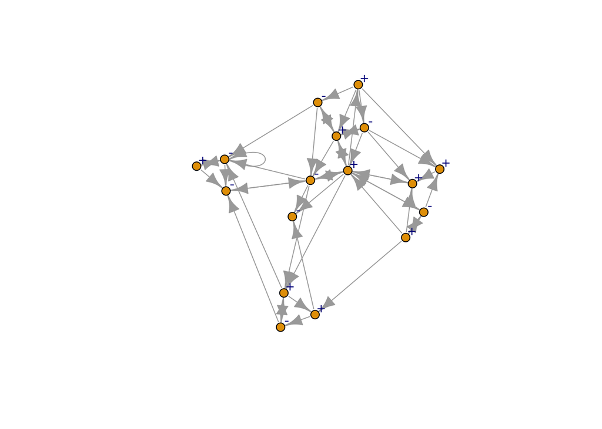

```r
graph <- set_vertex_attr(graph,"profit",value = c("+", "-", "+", "-", "+", "-", "+", "-", "+"))
plot(graph, vertex.label.dist=1,vertex.size=7, vertex.label = c("+", "-", "+", "-", "+", "-", "+", "-", "+"))
```

```r
vertex_attr(graph)
```

```
## $name
##  [1] "s01" "s02" "s03" "s04" "s05" "s06" "s07" "s08" "s09" "s10" "s11" "s12"
## [13] "s13" "s14" "s15" "s16" "s17"
##
## $media
##  [1] "NY Times"            "Washington Post"     "Wall Street Journal"
##  [4] "USA Today"           "LA Times"            "New York Post"
##  [7] "CNN"                 "MSNBC"               "FOX News"
## [10] "ABC"                 "BBC"                 "Yahoo News"
## [13] "Google News"         "Reuters.com"         "NYTimes.com"
## [16] "WashingtonPost.com"  "AOL.com"
##
## $media.type
##  [1] 1 1 1 1 1 1 2 2 2 2 2 3 3 3 3 3 3
##
## $type.label
##  [1] "Newspaper" "Newspaper" "Newspaper" "Newspaper" "Newspaper" "Newspaper"
##  [7] "TV"        "TV"        "TV"        "TV"        "TV"        "Online"
## [13] "Online"    "Online"    "Online"    "Online"    "Online"
##
## $audience.size
##  [1] 20 25 30 32 20 50 56 34 60 23 34 33 23 12 24 28 33
##
## $profit
##  [1] "+" "-" "+" "-" "+" "-" "+" "-" "+" "+" "-" "+" "-" "+" "-" "+" "-"
```

9. Create & set vertex attribute property named type and values(either leap or non-leap year)

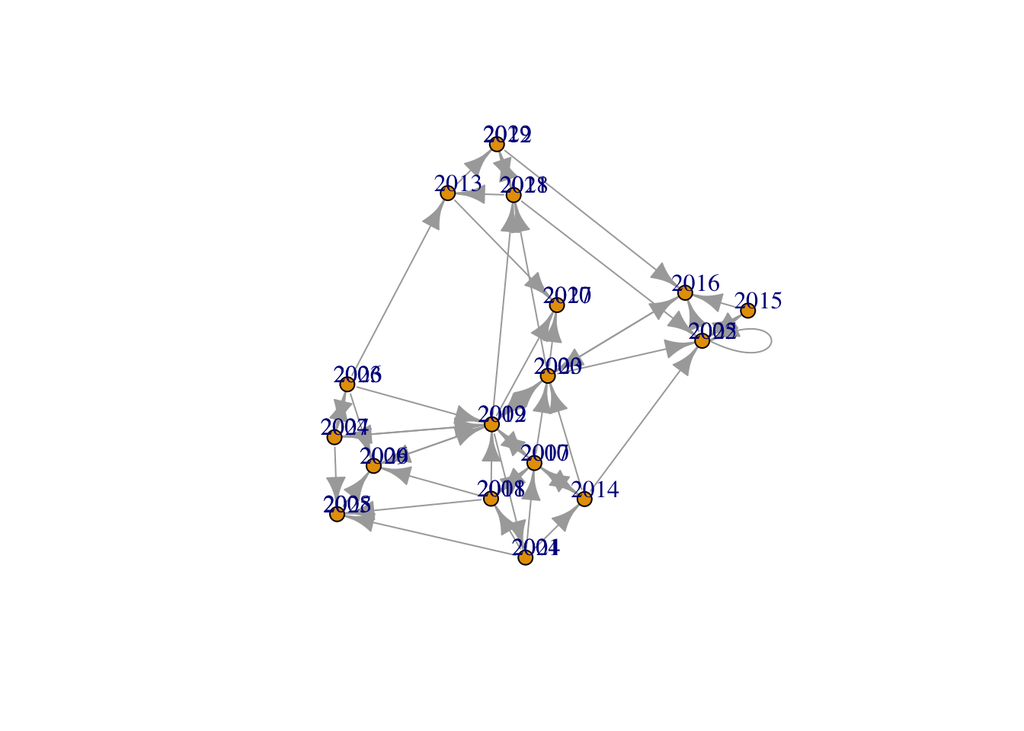

```r
graph <- set_vertex_attr(graph,"type",value = c(2000:2029))
plot(graph, vertex.label.dist=1,vertex.size=7, vertex.label = c(2000:2029))
```

```r
vertex_attr(graph)
```

```
## $name
##  [1] "s01" "s02" "s03" "s04" "s05" "s06" "s07" "s08" "s09" "s10" "s11" "s12"
## [13] "s13" "s14" "s15" "s16" "s17"
##
## $media
##  [1] "NY Times"            "Washington Post"     "Wall Street Journal"
##  [4] "USA Today"           "LA Times"            "New York Post"
##  [7] "CNN"                 "MSNBC"               "FOX News"
## [10] "ABC"                 "BBC"                 "Yahoo News"
## [13] "Google News"         "Reuters.com"         "NYTimes.com"
## [16] "WashingtonPost.com"  "AOL.com"
##
## $media.type
##  [1] 1 1 1 1 1 1 2 2 2 2 2 3 3 3 3 3 3
##
## $type.label
##  [1] "Newspaper" "Newspaper" "Newspaper" "Newspaper" "Newspaper" "Newspaper"
##  [7] "TV"        "TV"        "TV"        "TV"        "TV"        "Online"
## [13] "Online"    "Online"    "Online"    "Online"    "Online"
##
## $audience.size
##  [1] 20 25 30 32 20 50 56 34 60 23 34 33 23 12 24 28 33
##
## $profit
##  [1] "+" "-" "+" "-" "+" "-" "+" "-" "+" "+" "-" "+" "-" "+" "-" "+" "-"
##
## $type
##  [1] 2000 2001 2002 2003 2004 2005 2006 2007 2008 2009 2010 2011 2012 2013 2014
## [16] 2015 2016
```

10. Create & set edge attribute named weight and values (if edge exits in between leap year vertices then 5 else 1 )

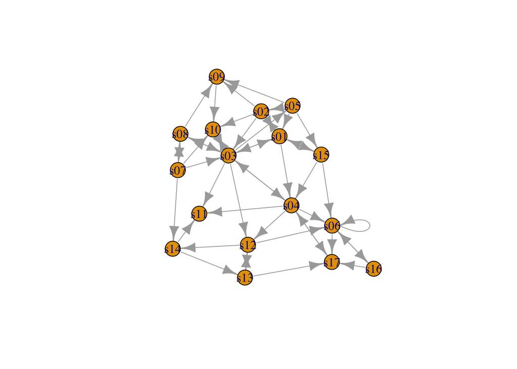

```r
# The 5 are in places of nodes where the edge connects 2 leap years. Else 1
graph <- set_edge_attr(graph,"weight",index = E(graph) ,value = c("5","1","1","1","5","1","1","1","5","1","1","1","5","1","1","1","5","1","1","1","5","1","1","1","5","1","1","5","1","1","1"))
plot(graph)
```

```r
get.edge.attribute(graph)
```

```
## $type
##  [1] "hyperlink" "hyperlink" "hyperlink" "mention"   "hyperlink" "hyperlink"
##  [7] "hyperlink" "hyperlink" "hyperlink" "hyperlink" "hyperlink" "hyperlink"
## [13] "mention"   "hyperlink" "hyperlink" "hyperlink" "mention"   "mention"
## [19] "hyperlink" "mention"   "mention"   "hyperlink" "hyperlink" "mention"
## [25] "hyperlink" "hyperlink" "mention"   "mention"   "mention"   "hyperlink"
## [31] "mention"   "hyperlink" "mention"   "mention"   "mention"   "hyperlink"
## [37] "mention"   "hyperlink" "mention"   "hyperlink" "mention"   "mention"
## [43] "mention"   "hyperlink" "hyperlink" "hyperlink" "hyperlink" "mention"
## [49] "hyperlink"
##
## $weight
##  [1] "5" "1" "1" "1" "5" "1" "1" "1" "5" "1" "1" "1" "5" "1" "1" "1" "5" "1" "1"
## [20] "1" "5" "1" "1" "1" "5" "1" "1" "5" "1" "1" "1" "5" "1" "1" "1" "5" "1" "1"
## [39] "1" "5" "1" "1" "1" "5" "1" "1" "1" "5" "1"
```

11. Convert the created un-directed graph into directed graph based on the following rule
1. edge directed towards high value vertex

```r
as.directed(graph, mode = c("arbitrary"))
```

```
## IGRAPH d4957b7 DNWB 17 49 --
## + attr: name (v/c), media (v/c), media.type (v/n), type.label (v/c),
## | audience.size (v/n), profit (v/c), type (v/n), type (e/c), weight
## | (e/c)
## + edges from d4957b7 (vertex names):
##  [1] s01->s02 s01->s03 s01->s04 s01->s15 s02->s01 s02->s03 s02->s09 s02->s10
##  [9] s03->s01 s03->s04 s03->s05 s03->s08 s03->s10 s03->s11 s03->s12 s04->s03
## [17] s04->s06 s04->s11 s04->s12 s04->s17 s05->s01 s05->s02 s05->s09 s05->s15
## [25] s06->s06 s06->s16 s06->s17 s07->s03 s07->s08 s07->s10 s07->s14 s08->s03
## [33] s08->s07 s08->s09 s09->s10 s10->s03 s12->s06 s12->s13 s12->s14 s13->s12
## [41] s13->s17 s14->s11 s14->s13 s15->s01 s15->s04 s15->s06 s16->s06 s16->s17
## + ... omitted several edges
```

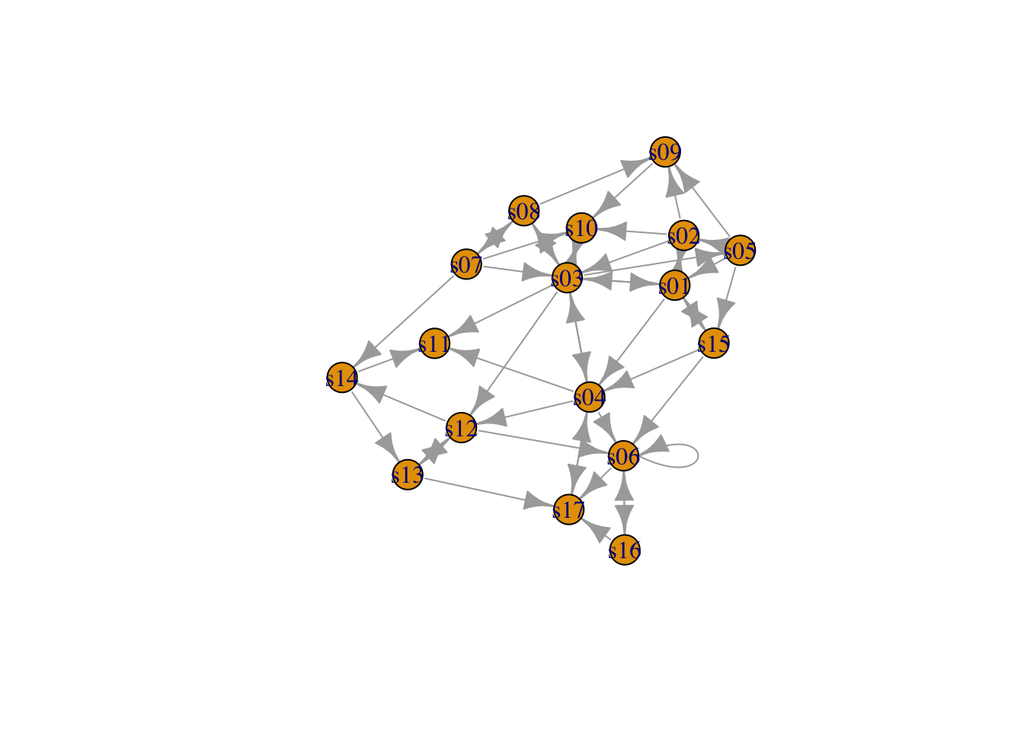

```r
plot(graph)
```

2. if any one of the vertex is leap year then put the reverse edge with same weight.

```r
as.directed(graph, mode = c("mutual"))
```

```
## IGRAPH 63ad93f DNWB 17 49 --
## + attr: name (v/c), media (v/c), media.type (v/n), type.label (v/c),
## | audience.size (v/n), profit (v/c), type (v/n), type (e/c), weight
## | (e/c)
## + edges from 63ad93f (vertex names):
##  [1] s01->s02 s01->s03 s01->s04 s01->s15 s02->s01 s02->s03 s02->s09 s02->s10
##  [9] s03->s01 s03->s04 s03->s05 s03->s08 s03->s10 s03->s11 s03->s12 s04->s03
## [17] s04->s06 s04->s11 s04->s12 s04->s17 s05->s01 s05->s02 s05->s09 s05->s15
## [25] s06->s06 s06->s16 s06->s17 s07->s03 s07->s08 s07->s10 s07->s14 s08->s03
## [33] s08->s07 s08->s09 s09->s10 s10->s03 s12->s06 s12->s13 s12->s14 s13->s12
## [41] s13->s17 s14->s11 s14->s13 s15->s01 s15->s04 s15->s06 s16->s06 s16->s17
## + ... omitted several edges
```

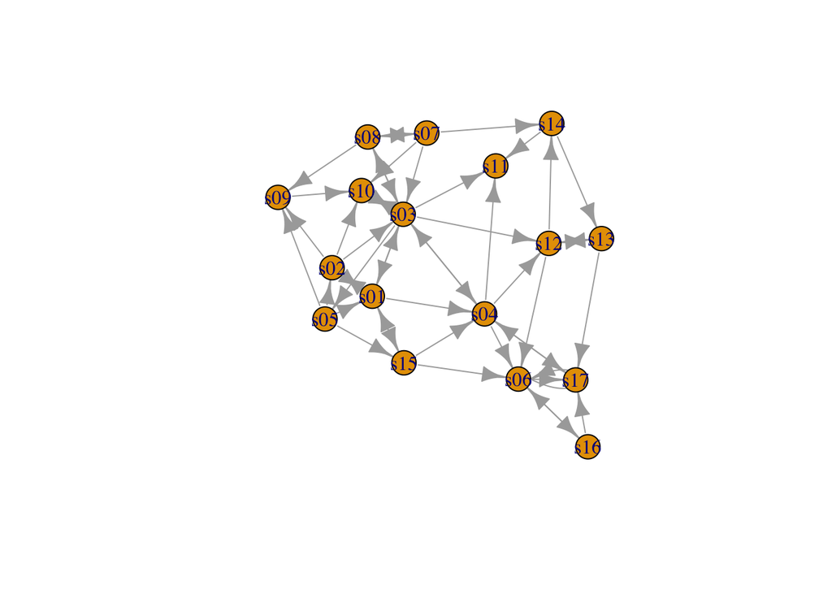

```r
plot(graph)
```

12. Display the adjacency matrix of the resultant directed graph.

```r
print(get.adjacency(graph))
```

```
## 17 x 17 sparse Matrix of class "dgCMatrix"
```

```
##    [[ suppressing 17 column names 's01', 's02', 's03' ... ]]
```

```
##
## s01 . 1 1 1 . . . . . . . . . . 1 . .
## s02 1 . 1 . . . . . 1 1 . . . . . . .
## s03 1 . . 1 1 . . 1 . 1 1 1 . . . . .
## s04 . . 1 . . 1 . . . . 1 1 . . . . 1
## s05 1 1 . . . . . . 1 . . . . . 1 . .
## s06 . . . . . 1 . . . . . . . . . 1 1
## s07 . . 1 . . . . 1 . 1 . . . 1 . . .
## s08 . . 1 . . . 1 . 1 . . . . . . . .
## s09 . . . . . . . . . 1 . . . . . . .
## s10 . . 1 . . . . . . . . . . . . . .
## s11 . . . . . . . . . . . . . . . . .
## s12 . . . . . 1 . . . . . . 1 1 . . .
## s13 . . . . . . . . . . . 1 . . . . 1
## s14 . . . . . . . . . . 1 . 1 . . . .
## s15 1 . . 1 . 1 . . . . . . . . . . .
## s16 . . . . . 1 . . . . . . . . . . 1
## s17 . . . 1 . . . . . . . . . . . . .
```

13. Display the in-degree and out-degree of each vertex of resultant directed graph

```r
print(degree(graph,mode="in"))
```

```
## s01 s02 s03 s04 s05 s06 s07 s08 s09 s10 s11 s12 s13 s14 s15 s16 s17
##   4   2   6   4   1   5   1   2   3   4   3   3   2   2   2   1   4
```

```r
print(degree(graph,mode="out"))
```

```
## s01 s02 s03 s04 s05 s06 s07 s08 s09 s10 s11 s12 s13 s14 s15 s16 s17
##   4   4   7   5   4   3   4   3   1   1   0   3   2   2   3   2   1
```